# R Notebook

## 1.[Skip] Preparation

All datasets have been merged into “ER_DRUG_DEATH_ACS.csv”. Jump to “2. Clean and Standardize”.

### 1.2 Data Preparation

```r
file_path <- "../Data/ER_opioid_2016_2019_cleaned.csv"
if (!file.exists(file_path)) {
  stop("File not found: Data/ER_opioid_2016_2019_cleaned.csv")
}
er_data <- read_csv(file_path, show_col_types = FALSE)

# Keep a subset of North / Central AL (as in your script)
keep_cnty <- toupper(c(
  "Lauderdale","Limestone","Madison","Jackson","Colbert","Franklin",
  "Lawrence","Morgan","Marshall","Dekalb","Marion","Winston",
  "Cullman","Blount","Etowah","Cherokee","Lamar","Fayette",
  "Walker","Jefferson","St. Clair","Pickens","Tuscaloosa","Shelby"
))

er_data <- er_data |>
  mutate(County = toupper(County),
         Date = as.Date(Date)) |>
  filter(County %in% keep_cnty)


# Read Data_ARCOS and clean for next process
Data_ARCOS <- read_csv("../BigData/ARCOS_AL_2016_2019_cleaned.csv")

Data_ARCOS_filted <- Data_ARCOS%>%
  filter(drug %in% c("OXYCODONE", "HYDROCODONE", "BUPRENORPHINE", "METHADONE"))%>%
  filter(county %in% toupper(c(
    "Lauderdale", "Limestone", "Madison", "Jackson", "Colbert", "Franklin",
    "Lawrence", "Morgan", "Marshall", "Dekalb", "Marion", "Winston",
    "Cullman", "Blount", "Etowah", "Cherokee", "Lamar", "Fayette",
    "Walker", "Jefferson", "St. Clair", "Pickens", "Tuscaloosa", "Shelby"
  ))
  )%>%
  #mutate(mme = mme/1000000)%>%
  mutate(Date = mdy(date))%>%
  mutate(County = toupper(county))

arcos_wide_mme <- Data_ARCOS_filted %>%
  pivot_wider(
    id_cols    = c(County, Date),
    names_from = drug,
    values_from= mme,
    values_fill = 0
  )

df_er_drug <- left_join(
  er_data,
  arcos_wide_mme,
  by = c("County", "Date")
)
```

### 1.3 ER and Drugs Annually aggregation + covariates

```r
# Presence at daily level
df_er_drug <- df_er_drug |>
  mutate(
    year = year(Date),
    presence = if_else(Count > 0, 1L, 0L)
  )

# Aggregate to county × year
df_er_drug_annual <- df_er_drug %>%
  group_by(County, year) %>%
  summarise(
    # population for the year (choose one: mean/first/median)
    pop_year = first(pop),

    # ER annual
    ER_annual = sum(Count, na.rm = TRUE),

    # Drug annual
    OXYCODONE_annual     = sum(OXYCODONE,     na.rm = TRUE),
    HYDROCODONE_annual   = sum(HYDROCODONE,   na.rm = TRUE),
    BUPRENORPHINE_annual = sum(BUPRENORPHINE, na.rm = TRUE),
    METHADONE_annual     = sum(METHADONE,     na.rm = TRUE),

    presence = as.integer(sum(Count, na.rm = TRUE) > 0),
    .groups = "drop"
  ) %>%
  mutate(
    # per-capita (proportion) and per 100k (common epidemiology scale)
    ER_annual_percapita           = ER_annual / pop_year,
    ER_annual_per100k             = ER_annual_percapita * 1e5,

    OXYCODONE_annual_percapita    = OXYCODONE_annual     / pop_year,
    OXYCODONE_annual_per100k      = OXYCODONE_annual_percapita * 1e5,

    HYDROCODONE_annual_percapita  = HYDROCODONE_annual   / pop_year,
    HYDROCODONE_annual_per100k    = HYDROCODONE_annual_percapita * 1e5,

    BUPRENORPHINE_annual_percapita = BUPRENORPHINE_annual / pop_year,
    BUPRENORPHINE_annual_per100k   = BUPRENORPHINE_annual_percapita * 1e5,

    METHADONE_annual_percapita    = METHADONE_annual     / pop_year,
    METHADONE_annual_per100k      = METHADONE_annual_percapita * 1e5
  )
```

### 1.4 CDC Opioid-related Mortality Read and Prepare

```r
mortality <- read_csv("../Data/CDCWonder Opioid Related Mortality AL 2016-2019.csv")

mortality_filted <- mortality%>%
  mutate(County = toupper(gsub(" County, AL", "", County)))%>%
  filter(County %in% toupper(c(
    "Lauderdale", "Limestone", "Madison", "Jackson", "Colbert", "Franklin",
    "Lawrence", "Morgan", "Marshall", "Dekalb", "Marion", "Winston",
    "Cullman", "Blount", "Etowah", "Cherokee", "Lamar", "Fayette",
    "Walker", "Jefferson", "St. Clair", "Pickens", "Tuscaloosa", "Shelby"
  )))%>%
  mutate(
    Deaths = suppressWarnings(as.numeric(Deaths)),      # "Suppressed" → NA
    CrudeRate = suppressWarnings(as.numeric(CrudeRate)),
    deaths_per100k = Deaths / Population * 1e5
  )%>%
  rename(year = Year,
         pop_CDC=Population)


# Merge
df_er_drug_mortality <- left_join(
  df_er_drug_annual,
  mortality_filted,
  by = c("County", "year")
)
```

### 1.5 ACS Data Read and Prepare

```r
unique(df_er_drug_mortality_acs$CountyCode)
```

```
 [1] 1009 1019 1033 1043 1055 1057 1059 1071 1073 1075 1077 1079 1083 1089 1093 1095 1103
[18] 1107 1117 1125 1127 1133
```

### [New] 1.6 NCHS Urban-Rural Data Read and Prepare

```r
summary(df_er_drug_mortality_acs_UR$CODE2023)
```

```
 2  3  4  5  6
16 16 20 16 20
```

### 1.7 Select Predictors in ACS

```r
df_er_drug_mortality_acs_UR$CODE2023
```

```
 [1] 2 2 2 2 6 6 6 6 4 4 4 4 5 5 5 5 4 4 4 4 6 6 6 6 5 5 5 5 5 5 5 5 2 2 2 2 6 6 6 6 4 4 4
[44] 4 4 4 4 4 3 3 3 3 3 3 3 3 6 6 6 6 5 5 5 5 4 4 4 4 3 3 3 3 2 2 2 2 3 3 3 3 2 2 2 2 6 6
[87] 6 6
Levels: 2 3 4 5 6
```

## 2. Clean and Standardize Data

### 2.1 Select Predictors

```r
# Read merged data
df_er_drug_mortality_acs <- read.csv("../Data/ER_DRUG_DEATH_ACS.csv")

df_select <- df_er_drug_mortality_acs%>%
  select(
    County,
    year,
    pop_CDC,
    # Deaths
    Deaths,
    # ER visit
    ER_annual_percapita,
    # Drugs
    OXYCODONE_annual_percapita, HYDROCODONE_annual_percapita,   BUPRENORPHINE_annual_percapita, METHADONE_annual_percapita,

    # ACS
    unemployee_rate,    gini_index, poverty_rate,   disability_rate, noinsurance_rate
    )
```

### 2.2 Data Standardization

```r
scale_vars <-  c(
    # Deaths
    "Deaths",
    # ER visit
    "ER_annual_percapita",
    # Drugs
    "OXYCODONE_annual_percapita",   "HYDROCODONE_annual_percapita", "BUPRENORPHINE_annual_percapita", "METHADONE_annual_percapita",

    # ACS
    "unemployee_rate",  "gini_index",   "poverty_rate", "disability_rate", "noinsurance_rate"
    )

df_select_z <- df_select %>%
  mutate(Deaths_rate= Deaths / pop_CDC)%>%
  mutate(across(all_of(scale_vars), ~ as.numeric(scale(.x)), .names = "{.col}_z"))


# df_select_z_cor <- df_select_z %>%
#   select(-c("County","year","pop_CDC"))%>%
#   select(-all_of(scale_vars))
```

## 3. Imputation of Death

### 3.1 EM Imputation of Death

#### 3.2.1 Initial Model without Spatiotemporal

```r
summary(fit_init)
```

```
Model fit by ML ['sdmTMB']
Formula: form_fixed
Mesh: NULL (isotropic covariance)
Data: data_fit
Family: nbinom1(link = 'log')

Conditional model:
                                 coef.est coef.se
(Intercept)                         -8.98    2.97
URcode                              -0.38    0.63
ER_annual_percapita_z               -0.40    0.26
OXYCODONE_annual_percapita_z         0.53    0.42
HYDROCODONE_annual_percapita_z      -0.54    0.88
BUPRENORPHINE_annual_percapita_z     1.51    0.73
METHADONE_annual_percapita_z         0.78    0.37
unemployee_rate_z                    1.02    1.67
gini_index_z                         0.01    0.28
poverty_rate_z                      -0.55    0.43
disability_rate_z                   -1.11    1.66
noinsurance_rate_z                   0.66    0.63

Dispersion parameter: 3.14
ML criterion at convergence: 88.223

See ?tidy.sdmTMB to extract these values as a data frame.
```

```r
summary(fit_init)
```

```
Model fit by ML ['sdmTMB']
Formula: form_fixed
Mesh: NULL (isotropic covariance)
Data: data_fit
Family: nbinom1(link = 'log')

Conditional model:
                                 coef.est coef.se
(Intercept)                         -8.98    2.97
URcode                              -0.38    0.63
ER_annual_percapita_z               -0.40    0.26
OXYCODONE_annual_percapita_z         0.53    0.42
HYDROCODONE_annual_percapita_z      -0.54    0.88
BUPRENORPHINE_annual_percapita_z     1.51    0.73
METHADONE_annual_percapita_z         0.78    0.37
unemployee_rate_z                    1.02    1.67
gini_index_z                         0.01    0.28
poverty_rate_z                      -0.55    0.43
disability_rate_z                   -1.11    1.66
noinsurance_rate_z                   0.66    0.63

Dispersion parameter: 3.14
ML criterion at convergence: 88.223

See ?tidy.sdmTMB to extract these values as a data frame.
```

```r
# Predict μ on ALL rows (including suppressed) using fixed+spatial init
p_init <- predict(fit_init, newdata = df_em, re_form = NA)  # include spatial RF from init
mu_hat <- exp(p_init$est)
phi <- exp(fit_init$parlist$ln_phi)
```

In EM method, we used basic model without spatial and spatiotemperol. We have tried full model, but it cannot converge, due to the limited sample size.

#### 3.2.2 Deterministic EM

Set the lower and upper bound

```r
df_final$Deaths_em
```

```
 [1]   6   7   9   9   1   1   0   1   0   0   0   1  13  11  11   3   9  27  15  14   0
[22]   1   1   1   1   0   0   0   0   1   1   1 166 162 140 143   0   1   0   0   5   4
[43]   5   3   1   1   1   1   4   5   6   6  16  20  12  33   0   3   0   5   0   6   9
[64]   9   8   7  15   9   0   0   0   0  28  27  24  22   9  14  12  17   9   9   9   9
[85]   0   0   2   2
```

EM converged at iter 10 (ΔLL=0.0000)

### 3.2 Fixed Imputation of Death

```r
#Impute missing Deaths with 5
df_imputated <- df_final %>%
  mutate(Deaths_5 = ifelse(is.na(Deaths), 5, Deaths),
         Deaths_1 = ifelse(is.na(Deaths), 1, Deaths),
         Deaths_9 = ifelse(is.na(Deaths), 9, Deaths)
         )%>%
  mutate(Deaths_5_z = scale(Deaths_5/pop_CDC),
         Deaths_1_z = scale(Deaths_1/pop_CDC),
         Deaths_9_z = scale(Deaths_9/pop_CDC),
         Deaths_em_z = scale(Deaths_em/pop_CDC),
         Deaths_em_rate = Deaths_em/pop_CDC,
         )

# No imputation
# mortality_filted_imputated <- mortality_filted
```

|  | Deaths | Deaths_1 | Deaths_5 | Deaths_9 | Deaths_em | Deaths_em_z |
| --- | --- | --- | --- | --- | --- | --- |
| 1 |  | 1 | 5 | 9 | 6 | [0.5390294995584524] |
| 2 |  | 1 | 5 | 9 | 7 | [0.7964920001383625] |
| 3 |  | 1 | 5 | 9 | 9 | [1.335671208933042] |
| 4 |  | 1 | 5 | 9 | 9 | [1.336252563593274] |
| 5 |  | 1 | 5 | 9 | 1 | [-0.4656895363650106] |
| 6 |  | 1 | 5 | 9 | 1 | [-0.4687519402114049] |
| 7 | 0 | 0 | 0 | 0 | 0 | [-1.065572689821206] |
| 8 |  | 1 | 5 | 9 | 1 | [-0.4764753420329702] |
| 9 | 0 | 0 | 0 | 0 | 0 | [-1.065572689821206] |
| 10 | 0 | 0 | 0 | 0 | 0 | [-1.065572689821206] |

[output cut: 78 more lines]

Imputing all suppressed deaths as a fixed value (5 for 1–9) can easily dampen or distort the spatial–temporal signal.

Why this can wash out spatiotemporal effects

Attenuation of variance: Replacing a whole range (1–9) with a single number shrinks true variability across counties/years. Less variance ⇒ weaker evidence for spatial or temporal structure.

Systematic bias: Suppression is not random (it occurs at low counts). Mid-point imputation pulls low-count areas toward the same value, making neighboring differences look smaller and weakening spatial gradients.

Few years (2016–2019): With only 4 time points, any variance compression makes AR(1)/IID effects even harder to estimate.

Per-capita scaling: If denominators vary a lot, a flat imputation in counts translates into uneven bias in rates, further masking structure.

What to do (quick, practical sensitivity checks)

1.Bracketing analysis (deterministic):

Refit with all suppressed set to 1 (lower bound) and to 9 (upper bound).

Compare AIC, σ_ST, and (if AR1) ρ across the three datasets (1, 5, 9). If σ_ST/ρ jump under 1 or 9, your ST result is sensitive to the imputation.

2.Multiple imputation (simple, nonparametric):

For each suppressed cell, draw a uniform integer 1–9; do this M times, fit the model to each, and pool σ_ST (and ρ).

3.Model-based imputation (better):

Fit a preliminary NB1 model without ST, predict μ̂, then for suppressed cells draw y ~ Truncated-NB(μ̂, θ; 1..9). Repeat M times and refit the full ST model. This respects your outcome distribution.

4.Interval-likelihood (best, Bayesian or custom):

Treat suppressed values as interval-censored counts (P(1≤Y≤9)). A Bayesian Poisson/NB BYM2/INLA model can incorporate this directly; in sdmTMB, you’d need custom likelihood.

## 4. Correlation of Predictors

### 4.1 Select Predictors

### 4.2 Data Standardization

```r
#Choose Death from Deaths, Deaths_rate, Deaths_1, Death_5, Death_9, Death_em
# Death_select <- "Deaths_em"
Death_select <- c("Deaths","Deaths_1", "Deaths_5", "Deaths_9","Deaths_em")

scale_vars <-  c(
    # Deaths
#######################################################

    #"Deaths"
    Death_select,
#######################################################
    # ER visit
    "ER_annual_percapita",
    # Drugs
    "OXYCODONE_annual_percapita",   "HYDROCODONE_annual_percapita", "BUPRENORPHINE_annual_percapita", "METHADONE_annual_percapita",

    # ACS
    "unemployee_rate",  "gini_index",   "poverty_rate", "disability_rate", "noinsurance_rate"
    )

df_cor_rate <- df_cor %>%
  mutate(Deaths_rate = Deaths / pop_CDC)%>%
  mutate(Deaths_1_rate = Deaths_1 / pop_CDC)%>%
  mutate(Deaths_5_rate = Deaths_5 / pop_CDC)%>%
  mutate(Deaths_9_rate = Deaths_9 / pop_CDC)%>%
  mutate(Deaths_em_rate = Deaths_em / pop_CDC)%>%
  mutate(across(all_of(scale_vars), ~ as.numeric(scale(.x)), .names = "{.col}_z"))


df_cor_rate_only_cor <- df_cor_rate %>%
  select(-c("County","year","pop_CDC"))%>%
  select(-all_of(scale_vars))
```

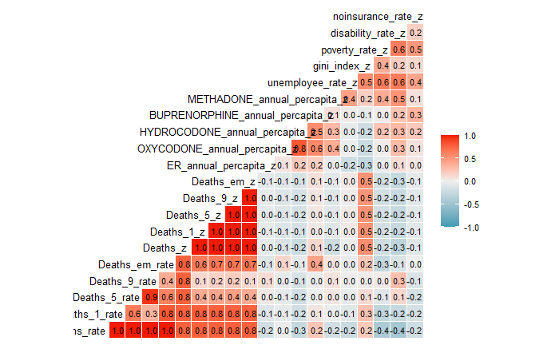

```r
p_heat <- ggcorr(
  df_cor_rate_only_cor ,
  method = c("pairwise.complete.obs", "pearson"),
  label = TRUE, label_size = 3, hjust = 0.9, layout.exp = 1
) + theme_minimal(base_size = 10)
print(p_heat)
```

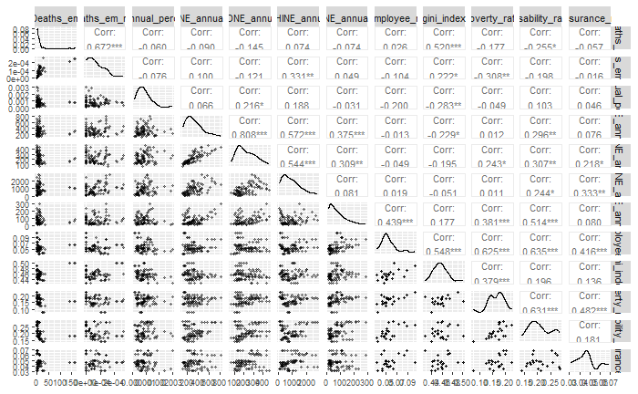

#### 4.2.1 Check Collinearity

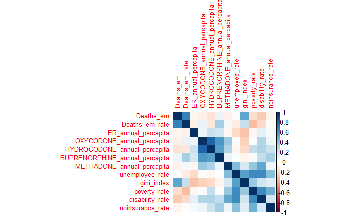

#### 4.2.2 Variance Inflation Factor (VIF)

```r
vif_values
```

```
           ER_annual_percapita     OXYCODONE_annual_percapita
                      1.327957                       4.840518
  HYDROCODONE_annual_percapita BUPRENORPHINE_annual_percapita
                      4.741489                       2.222605
    METHADONE_annual_percapita                unemployee_rate
                      1.716352                       3.981195
                    gini_index                   poverty_rate
                      1.847158                       3.680465
               disability_rate               noinsurance_rate
                      3.635219                       2.252041
```

VIF < 3 → No concern

3–5 → Mild collinearity

5–10 → Consider removing / combining predictors

#>10 → Serious multicollinearity

## 5. Spatiotemporal Model [Updated]

### 5.1 County geometry & coordinates

```r
# AL counties in UTM 16N (meters), then convert to km numeric coords
counties_sf <- tigris::counties(state = "AL", cb = TRUE, year = 2023) |>
  st_transform(26916) |>
  mutate(County = toupper(NAME))

coords_m  <- st_coordinates(st_centroid(st_geometry(counties_sf)))
county_xy <- counties_sf |>
  st_drop_geometry() |>
  transmute(
    County,
    X = coords_m[, "X"] / 1000,  # km
    Y = coords_m[, "Y"] / 1000
  )

# Merge coords into model frame
df <- df_cor_rate |>
  left_join(county_xy, by = "County") |>
  filter(is.finite(X), is.finite(Y), is.finite(pop_CDC))%>%
  mutate(time_index = match(year, sort(unique(year))),
         log_pop    = log(pop_CDC))
```

#### 5.1.1 Mesh

```r
### Mesh (built on the data actually modeled)
# Cutoff ~ 10% of X-range in km (tune if too coarse/fine)
mesh <- make_mesh(
  df,
  xy_cols = c("X","Y"),
  cutoff = diff(range(df$X, na.rm = TRUE)) / 10
)
```

### 5.2 Create Formula

```r
# ## MODEL FORMULAS ( "." = additive, "x" = interaction )
#
# ## Full main-effects model (ER . opioids . SES)
# form_ER.All <- as.formula(
#   Deaths_em_rate ~ ER_annual_percapita_z +                 # ER visits
#     OXYCODONE_annual_percapita_z +                        # opioid types
#     HYDROCODONE_annual_percapita_z +
#     BUPRENORPHINE_annual_percapita_z +
#     METHADONE_annual_percapita_z +
#     unemployee_rate_z + gini_index_z +
#     poverty_rate_z + disability_rate_z + noinsurance_rate_z
# )
#
# ## ER only
# form_ER <- as.formula(
#   Deaths_em_rate ~ ER_annual_percapita_z
# )
#
# ## ER . Opioids (additive)
# form_ER.Opioid <- as.formula(
#   Deaths_em_rate ~ ER_annual_percapita_z +
#     OXYCODONE_annual_percapita_z +
#     HYDROCODONE_annual_percapita_z +
#     BUPRENORPHINE_annual_percapita_z +
#     METHADONE_annual_percapita_z
# )
#
# ## ER . SES (additive)
# form_ER.SES <- as.formula(
#   Deaths_em_rate ~ ER_annual_percapita_z +
#     unemployee_rate_z + gini_index_z +
#     poverty_rate_z + disability_rate_z + noinsurance_rate_z
# )
#
# ## ER . Time (additive linear)
# form_ER.Time <- as.formula(
#   Deaths_em_rate ~ ER_annual_percapita_z +
#     time_index
# )
#
# ## ER . SplineTime (additive nonlinear)
# form_ER.Spline <- as.formula(
#   Deaths_em_rate ~ ER_annual_percapita_z +
#     s(time_index, k = 4)
# )
#
# ## ER x Time (interaction)
# form_ERxTime <- as.formula(
#   Deaths_em_rate ~ ER_annual_percapita_z * time_index
# )
#
# ## ER . SES . SplineTime (additive, no interaction)
# form_ER.SES.Spline <- as.formula(
#   Deaths_em_rate ~ ER_annual_percapita_z +
#     unemployee_rate_z + gini_index_z +
#     poverty_rate_z + disability_rate_z + noinsurance_rate_z +
#     s(time_index, k = 4)
# )
#
# ## ER x Opioid . SES (ER interacts with opioids; SES additive)
# form_ERxOpioid.SES <- as.formula(
#   Deaths_em_rate ~
#     ER_annual_percapita_z * (
#       OXYCODONE_annual_percapita_z +
#       HYDROCODONE_annual_percapita_z +
#       BUPRENORPHINE_annual_percapita_z +
#       METHADONE_annual_percapita_z
#     ) +
#     unemployee_rate_z + gini_index_z +
#     poverty_rate_z + disability_rate_z + noinsurance_rate_z
# )
#
# ## ER x SES . Opioid (ER interacts with SES; opioids additive)
# form_ERxSES.Opioid <- as.formula(
#   Deaths_em_rate ~
#     ER_annual_percapita_z * (
#       unemployee_rate_z + gini_index_z +
#       poverty_rate_z + disability_rate_z + noinsurance_rate_z
#     ) +
#     OXYCODONE_annual_percapita_z +
#     HYDROCODONE_annual_percapita_z +
#     BUPRENORPHINE_annual_percapita_z +
#     METHADONE_annual_percapita_z
# )
#
# ## ER x (Opioid + SES) . Spline (maximal interaction)
# form_ERxOpioidSES.Spline <- as.formula(
#   Deaths_em_rate ~
#     ER_annual_percapita_z * (
#       OXYCODONE_annual_percapita_z +
#       HYDROCODONE_annual_percapita_z +
#       BUPRENORPHINE_annual_percapita_z +
#       METHADONE_annual_percapita_z +
#       unemployee_rate_z + gini_index_z +
#       poverty_rate_z + disability_rate_z + noinsurance_rate_z
#     ) +
#     s(time_index, k = 4)
# )
#
# form_ERxOpioidSES.Time <- as.formula(
#   Deaths_em_rate ~
#     ER_annual_percapita_z * (
#       OXYCODONE_annual_percapita_z +
#       HYDROCODONE_annual_percapita_z +
#       BUPRENORPHINE_annual_percapita_z +
#       METHADONE_annual_percapita_z +
#       unemployee_rate_z + gini_index_z +
#       poverty_rate_z + disability_rate_z + noinsurance_rate_z
#     ) +
#     time_index
# )
```

#### Create Formula for Deaths_em, instead of Death rate

```r
## MODEL FORMULAS ( "." = additive, "x" = interaction )

## Full main-effects model (ER . opioids . SES)
form_ER.All <- as.formula(
  Deaths_em ~ CODE2023 + ER_annual_percapita_z +                 # ER visits
    OXYCODONE_annual_percapita_z +                    # opioid types
    HYDROCODONE_annual_percapita_z +
    BUPRENORPHINE_annual_percapita_z +
    METHADONE_annual_percapita_z +
    unemployee_rate_z + gini_index_z +
    poverty_rate_z + disability_rate_z + noinsurance_rate_z
)

## ER only
form_ER <- as.formula(
  Deaths_em ~ CODE2023 + ER_annual_percapita_z
)

## ER . Opioids (additive)
form_ER.Opioid <- as.formula(
  Deaths_em ~ CODE2023 + ER_annual_percapita_z +
    OXYCODONE_annual_percapita_z +
    HYDROCODONE_annual_percapita_z +
    BUPRENORPHINE_annual_percapita_z +
    METHADONE_annual_percapita_z
)

## ER . SES (additive)
form_ER.SES <- as.formula(
  Deaths_em ~ CODE2023 + ER_annual_percapita_z +
    unemployee_rate_z + gini_index_z +
    poverty_rate_z + disability_rate_z + noinsurance_rate_z
)

## ER . Time (additive linear)
form_ER.Time <- as.formula(
  Deaths_em ~ CODE2023 + ER_annual_percapita_z +
    time_index
)

## ER . SplineTime (additive nonlinear)
form_ER.Spline <- as.formula(
  Deaths_em ~ CODE2023 + ER_annual_percapita_z +
    s(time_index, k = 4)
)

## ER x Time (interaction)
form_ERxTime <- as.formula(
  Deaths_em ~ CODE2023 + ER_annual_percapita_z * time_index
)

## ER . SES . SplineTime (additive, no interaction)
form_ER.SES.Spline <- as.formula(
  Deaths_em ~ CODE2023 + ER_annual_percapita_z +
    unemployee_rate_z + gini_index_z +
    poverty_rate_z + disability_rate_z + noinsurance_rate_z +
    s(time_index, k = 4)
)

## ER x Opioid . SES (ER interacts with opioids; SES additive)
form_ERxOpioid.SES <- as.formula(
  Deaths_em ~ CODE2023 +
    ER_annual_percapita_z * (
      OXYCODONE_annual_percapita_z +
      HYDROCODONE_annual_percapita_z +
      BUPRENORPHINE_annual_percapita_z +
      METHADONE_annual_percapita_z
    ) +
    unemployee_rate_z + gini_index_z +
    poverty_rate_z + disability_rate_z + noinsurance_rate_z
)

## ER x SES . Opioid (ER interacts with SES; opioids additive)
form_ERxSES.Opioid <- as.formula(
  Deaths_em ~ CODE2023 +
    ER_annual_percapita_z * (
      unemployee_rate_z + gini_index_z +
      poverty_rate_z + disability_rate_z + noinsurance_rate_z
    ) +
    OXYCODONE_annual_percapita_z +
    HYDROCODONE_annual_percapita_z +
    BUPRENORPHINE_annual_percapita_z +
    METHADONE_annual_percapita_z
)

## ER x (Opioid + SES) . Spline (maximal interaction)
form_ERxOpioidSES.Spline <- as.formula(
  Deaths_em ~ CODE2023 +
    ER_annual_percapita_z * (
      OXYCODONE_annual_percapita_z +
      HYDROCODONE_annual_percapita_z +
      BUPRENORPHINE_annual_percapita_z +
      METHADONE_annual_percapita_z +
      unemployee_rate_z + gini_index_z +
      poverty_rate_z + disability_rate_z + noinsurance_rate_z
    ) +
    s(time_index, k = 4)
)

form_ERxOpioidSES.Time <- as.formula(
  Deaths_em ~ CODE2023 +
    ER_annual_percapita_z * (
      OXYCODONE_annual_percapita_z +
      HYDROCODONE_annual_percapita_z +
      BUPRENORPHINE_annual_percapita_z +
      METHADONE_annual_percapita_z +
      unemployee_rate_z + gini_index_z +
      poverty_rate_z + disability_rate_z + noinsurance_rate_z
    ) +
    time_index
)
```

#### Try Formula for difference imputation

```r
## MODEL FORMULAS ( "." = additive, "x" = interaction )

## Full main-effects model (ER . opioids . SES)
form_ER.All <- as.formula(
  Deaths_9 ~ ER_annual_percapita_z +                 # ER visits
    OXYCODONE_annual_percapita_z +                    # opioid types
    HYDROCODONE_annual_percapita_z +
    BUPRENORPHINE_annual_percapita_z +
    METHADONE_annual_percapita_z +
    unemployee_rate_z + gini_index_z +
    poverty_rate_z + disability_rate_z + noinsurance_rate_z
)

## ER only
form_ER <- as.formula(
  Deaths_9 ~ ER_annual_percapita_z
)

## ER . Opioids (additive)
form_ER.Opioid <- as.formula(
  Deaths_9 ~ ER_annual_percapita_z +
    OXYCODONE_annual_percapita_z +
    HYDROCODONE_annual_percapita_z +
    BUPRENORPHINE_annual_percapita_z +
    METHADONE_annual_percapita_z
)

## ER . SES (additive)
form_ER.SES <- as.formula(
  Deaths_9 ~ ER_annual_percapita_z +
    unemployee_rate_z + gini_index_z +
    poverty_rate_z + disability_rate_z + noinsurance_rate_z
)

## ER . Time (additive linear)
form_ER.Time <- as.formula(
  Deaths_9 ~ ER_annual_percapita_z +
    time_index
)

## ER . SplineTime (additive nonlinear)
form_ER.Spline <- as.formula(
  Deaths_9 ~ ER_annual_percapita_z +
    s(time_index, k = 4)
)

## ER x Time (interaction)
form_ERxTime <- as.formula(
  Deaths_9 ~ ER_annual_percapita_z * time_index
)

## ER . SES . SplineTime (additive, no interaction)
form_ER.SES.Spline <- as.formula(
  Deaths_9 ~ ER_annual_percapita_z +
    unemployee_rate_z + gini_index_z +
    poverty_rate_z + disability_rate_z + noinsurance_rate_z +
    s(time_index, k = 4)
)

## ER x Opioid . SES (ER interacts with opioids; SES additive)
form_ERxOpioid.SES <- as.formula(
  Deaths_9 ~
    ER_annual_percapita_z * (
      OXYCODONE_annual_percapita_z +
      HYDROCODONE_annual_percapita_z +
      BUPRENORPHINE_annual_percapita_z +
      METHADONE_annual_percapita_z
    ) +
    unemployee_rate_z + gini_index_z +
    poverty_rate_z + disability_rate_z + noinsurance_rate_z
)

## ER x SES . Opioid (ER interacts with SES; opioids additive)
form_ERxSES.Opioid <- as.formula(
  Deaths_9 ~
    ER_annual_percapita_z * (
      unemployee_rate_z + gini_index_z +
      poverty_rate_z + disability_rate_z + noinsurance_rate_z
    ) +
    OXYCODONE_annual_percapita_z +
    HYDROCODONE_annual_percapita_z +
    BUPRENORPHINE_annual_percapita_z +
    METHADONE_annual_percapita_z
)

## ER x (Opioid + SES) . Spline (maximal interaction)
form_ERxOpioidSES.Spline <- as.formula(
  Deaths_9 ~
    ER_annual_percapita_z * (
      OXYCODONE_annual_percapita_z +
      HYDROCODONE_annual_percapita_z +
      BUPRENORPHINE_annual_percapita_z +
      METHADONE_annual_percapita_z +
      unemployee_rate_z + gini_index_z +
      poverty_rate_z + disability_rate_z + noinsurance_rate_z
    ) +
    s(time_index, k = 4)
)

form_ERxOpioidSES.Time <- as.formula(
  Deaths_9 ~
    ER_annual_percapita_z * (
      OXYCODONE_annual_percapita_z +
      HYDROCODONE_annual_percapita_z +
      BUPRENORPHINE_annual_percapita_z +
      METHADONE_annual_percapita_z +
      unemployee_rate_z + gini_index_z +
      poverty_rate_z + disability_rate_z + noinsurance_rate_z
    ) +
    time_index
)
```

### 5.3 Model Comparison and Curvature Testing (For EM) [Updated]

### 5.4 extract the coefficient estimate for ER_annual_percapita_z

```r
# --- extract coefficient info for ER_annual_percapita_z ---
coef_info <- lapply(names(fits), function(mname) {
  fit_i <- fits[[mname]]
  if (inherits(fit_i, "sdmTMB")) {
    td <- tryCatch(broom::tidy(fit_i), error = function(e) NULL)
    if (!is.null(td) && "term" %in% names(td)) {



      row <- td[td$term == "ER_annual_percapita_z", c("term", "estimate", "std.error"), drop = FALSE]
      # row <- td[td$term == "ER_annual_percapita_z", c("term", "estimate", "std.error"), drop = FALSE]
      if (nrow(row) == 1) {
        return(tibble(
          model = mname,
          coef_est = round(row$estimate,3),
          coef_se = round(row$std.error,3)
        ))
      }
    }
  }
  tibble(model = mname, coef_est = NA_real_, coef_se = NA_real_)
})

coef_df <- bind_rows(coef_info)

# --- join back to AIC table ---
aic_table_coef <- aic_table %>%
  left_join(coef_df, by = "model")

# view top models
#print(aic_table_coef %>% select(model, AIC, DeltaAIC, coef_est, coef_se))

datatable(
  aic_table_coef,
  filter = "top",
  options = list(
    pageLength = 50,
    autoWidth = TRUE
  )
)
```

|  | model | family | spatial | spatiotemporal | form | AIC | logLik | npar | hessian_pd | grad_max | converged_strict | n_warnings | warn_hessian | warn_nan | first_warning | DeltaAIC | coef_est | coef_se |
| --- | --- | --- | --- | --- | --- | --- | --- | --- | --- | --- | --- | --- | --- | --- | --- | --- | --- | --- |
| 1 | NB2_spOFF_OFF_form_ER.All | NB2 | off | off | form_ER.All | 389.0754784688942 | -178.5377392344471 | 16 | True | 1.651404568647763e-10 | True | 0 | False | False |  | 0 | -0.038 | 0.095 |
| 2 | Poisson_spOFF_AR1_form_ER.All | Poisson | off | ar1 | form_ER.All | 391.9413966959834 | -177.9706983479917 | 18 | True | 1.799634885557566e-10 | True | 0 | False | False |  | 2.865918227089196 | -0.054 | 0.097 |
| 3 | NB2_spOFF_OFF_form_ERxSES.Opioid | NB2 | off | off | form_ERxSES.Opioid | 393.0254282713423 | -175.5127141356711 | 21 | True | 9.901476860640912e-10 | True | 0 | False | False |  | 3.949949802448032 | 0.022 | 0.116 |
| 4 | NB2_spON_OFF_form_ER.All | NB2 | on | off | form_ER.All | 393.0754784708499 | -178.537739235425 | 18 | False | 9.448993117814003e-09 | False | 2 | True | True | NaNs produced | 4.000000001955698 | -0.038 | 0.095 |
| 5 | Poisson_spOFF_OFF_form_ERxOpioidSES.Time | Poisson | off | off | form_ERxOpioidSES.Time | 393.1413213200535 | -171.5706606600268 | 25 | True | 3.679917481846928e-12 | True | 0 | False | False |  | 4.065842851159289 | 0.082 | 0.125 |
| 6 | Poisson_spON_AR1_form_ER.All | Poisson | on | ar1 | form_ER.All | 393.9413966959919 | -177.9706983479959 | 19 | True | 8.371303650278605e-11 | True | 0 | False | False |  | 4.865918227097666 | -0.054 | 0.097 |
| 7 | Poisson_spOFF_OFF_form_ER.All | Poisson | off | off | form_ER.All | 395.0077953642539 | -182.5038976821269 | 15 | True | 5.233591338082988e-13 | True | 0 | False | False |  | 5.932316895359634 | -0.088 | 0.084 |
| 8 | NB2_spOFF_AR1_form_ER.All | NB2 | off | ar1 | form_ER.All | 395.0754761813967 | -178.5377380906984 | 19 | False | 0.0001086005868881998 | False | 2 | True | True | NaNs produced | 5.999997712502477 | -0.038 | 0.095 |
| 9 | Poisson_spOFF_OFF_form_ERxOpioidSES.Spline | Poisson | off | off | form_ERxOpioidSES.Spline | 395.1413213222046 | -171.5706606611023 | 26 | True | 3.772248265755722e-08 | True | 0 | False | False |  | 6.065842853310357 | 0.082 | 0.125 |
| 10 | NB2_spOFF_OFF_form_ERxOpioidSES.Time | NB2 | off | off | form_ERxOpioidSES.Time | 395.1413216914907 | -171.5706608457454 | 26 | True | 2.029903484433715e-07 | True | 0 | False | False |  | 6.06584322259647 | 0.082 | 0.125 |

[output cut: 86 more lines]

```r
#write.csv(aic_table_coef, "output/aic_table_coef.csv", row.names = FALSE)



saveRDS(aic_table_coef, "../Shiny/aic_table_coef.rds")

save(
  df,
  fits,
  aic_table_coef,
  file = "../Shiny/models.RData"
)
```

### 5.4 Explore specific model

```r
# Find the row for the combo

family.select = "Poisson"  # Replace with "Poisson", "NB1", "NB2"
spatial.select = "on"      # Replace with "on", "off"
spatiotemporla.select = "ar1"     # Replace with "off", "iid", "ar1"
form.select = "form_ERxOpioidSES.Time"                  #"form",  "form.er",  "form.er.cov",  "form.inter.cov",   "form.er.spline",  "form.er.cov.spline",  "form.inter.cov.spline"



idx <- with(aic_table, which(family == family.select &
                               spatial == spatial.select &
                               spatiotemporal == spatiotemporla.select &
                               form == form.select))

stopifnot(length(idx) == 1)          # ensure it exists uniquely
fit <- fits[[idx]]      # create the named object you expected

summary(fit)
```

[output not shown]

```r
sanity(fit)
```

#### 5.4.1 Try extra optimization

```r
fit_nb2_full <- fit

fit_nb2_full_extra <- run_extra_optimization(fit_nb2_full)

sanity(fit_nb2_full_extra)
```

```r
max(abs(fit_nb2_full_extra$sd_report$gradient.fixed), na.rm = TRUE)
```

```
[1] 1.221364e-08
```

#### 5.4.2 Which parameter is causing the residual gradient?

```r
fit_nb2_full_extra$sd_report$gradient.fixed
```

```
[1]  3.721294e-10  9.353382e-10  1.996831e-10  8.096746e-10  1.016228e-10  6.763003e-11
[7] -1.247430e-10  1.221364e-08  9.512702e-10
```

```r
sort(abs(fit_nb2_full_extra$sd_report$gradient.fixed), decreasing = TRUE)
```

```
[1] 1.221364e-08 9.512702e-10 9.353382e-10 8.096746e-10 3.721294e-10 1.996831e-10
[7] 1.247430e-10 1.016228e-10 6.763003e-11
```

If this were ecology (fish stock assessment):

→ reviewers accept gradients < 0.01

If this were epidemiology / applied ML / public health:

→ gradients < 0.005 are often accepted → especially with spatial models

If this were statistics / econometrics journal:

→ they expect gradients < 0.001 → but you can still justify your model with:

sanity() output

residual diagnostics

AIC

robustness checks with simpler models

#### 5.4.3 For Model 38 NB2_spON_AR1_form_ERxOpioidSES.Time

```r
# Find the row for the combo

family.select = "NB2"  # Replace with "Poisson", "NB1", "NB2"
spatial.select = "on"      # Replace with "on", "off"
spatiotemporla.select = "ar1"     # Replace with "off", "iid", "ar1"
form.select = "form_ERxOpioidSES.Time"                  #"form",  "form.er",  "form.er.cov",  "form.inter.cov",   "form.er.spline",  "form.er.cov.spline",  "form.inter.cov.spline"



idx <- with(aic_table, which(family == family.select &
                               spatial == spatial.select &
                               spatiotemporal == spatiotemporla.select &
                               form == form.select))

stopifnot(length(idx) == 1)          # ensure it exists uniquely
fit <- fits[[idx]]      # create the named object you expected

summary(fit)
```

[output not shown]

```r
sanity(fit)
```

Model 38 NB2_spON_AR1_form_ERxOpioidSES.Time (AIC = 423.5) [robustness check] We fit a negative binomial spatiotemporal model with spatial random effects and AR1 correlation. The estimated dispersion parameter was extremely large and the spatiotemporal variance collapsed to ≈0, indicating that a simpler spatial Poisson model provided an adequate fit. Results were virtually identical under both specifications; we report the spatial model with linear time and ER×opioid×SES interactions.

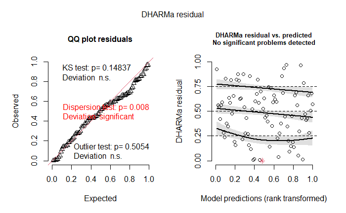

```r
mname <- aic_table_coef$model[which.min(aic_table_coef$AIC)]
fit   <- fits[[mname]]

set.seed(123)
sims <- simulate(fit, nsim = 250, type = "mle-mvn")

# Option 1: get DHARMa object directly
dh <- sdmTMB::dharma_residuals(
  simulated_response = sims,
  object             = fit,
  plot               = FALSE,
  return_DHARMa      = TRUE
)

plot(dh)                         # DHARMa default diagnostic plot
```

```
    DHARMa nonparametric dispersion test via sd of residuals fitted vs. simulated

data:  simulationOutput
dispersion = 0.3589, p-value = 0.008
alternative hypothesis: two.sided
```

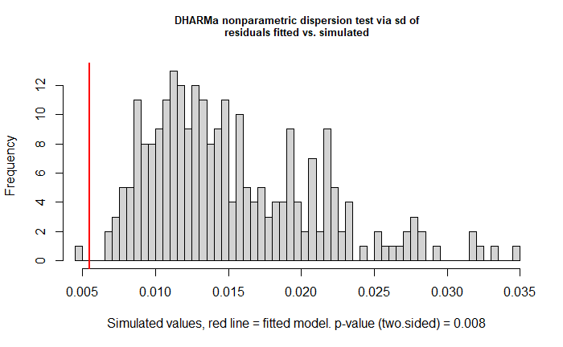

```r
DHARMa::testDispersion(dh)
```

```
    Exact one-sample Kolmogorov-Smirnov test

data:  simulationOutput$scaledResiduals
D = 0.11964, p-value = 0.1484
alternative hypothesis: two-sided
```

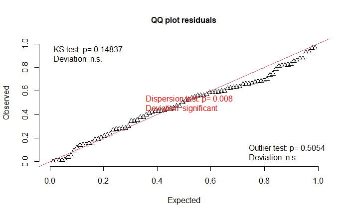

```r
DHARMa::testUniformity(dh)
```

```
    DHARMa zero-inflation test via comparison to expected zeros with simulation
    under H0 = fitted model

data:  simulationOutput
ratioObsSim = 1.0969, p-value = 0.608
alternative hypothesis: two.sided
```

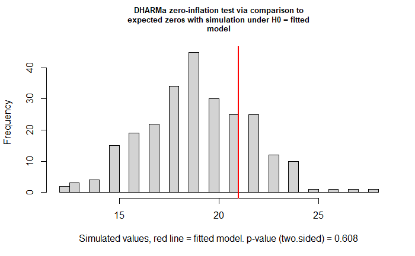

```r
DHARMa::testZeroInflation(dh)
```

### 5.4.1 Explore Selected Four Models in Last Week [New]

```r
# Define the model names you want
model_names <- c(
  "Poisson_spOFF_OFF_form_ER",
  "Poisson_spOFF_OFF_form_ERxOpioid.SES",
  "Poisson_spOFF_OFF_form_ERxOpioid.SES",
  "Poisson_spON_OFF_form_ERxOpioid.SES"
)


# Check which exist in the fits list
model_names <- model_names[model_names %in% names(fits)]

# Extract coefficients for each
coef_list <- lapply(model_names, function(m) {
  fit_i <- fits[[m]]
  if (inherits(fit_i, "sdmTMB")) {
    coefs <- broom::tidy(fit_i)
    coefs$model <- m
    coefs
  } else {
    warning(sprintf("Model %s not found or invalid.", m))
    NULL
  }
})

# Combine into one table
coef_table <- dplyr::bind_rows(coef_list)

print(coef_table)
```

| term | estimate | std.error | conf.low | conf.high | model |
| --- | --- | --- | --- | --- | --- |
| (Intercept) | -9.062628415 | 0.03036652 | -9.12214571 | -9.003111120 | Poisson_spOFF_OFF_form_ER |
| ER_annual_percapita_z | 0.019035988 | 0.04142370 | -0.06215297 | 0.100224949 | Poisson_spOFF_OFF_form_ER |
| (Intercept) | -9.786369294 | 0.07533834 | -9.93402973 | -9.638708855 | Poisson_spOFF_OFF_form_ERxOpioid.SES |
| ER_annual_percapita_z | -0.169230059 | 0.08692686 | -0.33960358 | 0.001143461 | Poisson_spOFF_OFF_form_ERxOpioid.SES |
| OXYCODONE_annual_percapita_z | -0.012846269 | 0.12866934 | -0.26503353 | 0.239340996 | Poisson_spOFF_OFF_form_ERxOpioid.SES |
| HYDROCODONE_annual_percapita_z | -0.240195330 | 0.15976153 | -0.55332218 | 0.072931519 | Poisson_spOFF_OFF_form_ERxOpioid.SES |
| BUPRENORPHINE_annual_percapita_z | 0.609540356 | 0.07888798 | 0.45492275 | 0.764157957 | Poisson_spOFF_OFF_form_ERxOpioid.SES |
| METHADONE_annual_percapita_z | 0.418462016 | 0.07861646 | 0.26437658 | 0.572547449 | Poisson_spOFF_OFF_form_ERxOpioid.SES |
| unemployee_rate_z | -0.036940197 | 0.16166658 | -0.35380088 | 0.279920481 | Poisson_spOFF_OFF_form_ERxOpioid.SES |
| gini_index_z | 0.452066152 | 0.06567789 | 0.32333985 | 0.580792452 | Poisson_spOFF_OFF_form_ERxOpioid.SES |

[output cut: 37 more lines]

```r
#write.csv(coef_table, "output/coef_table.csv")
```

```r
summary(fit)$coefficients
```

```
Spatiotemporal model fit by ML ['sdmTMB']
Formula: form_obj
Mesh: mesh (isotropic covariance)
Time column: time_arg
Data: df
Family: poisson(link = 'log')

Conditional model:
                                 coef.est coef.se
(Intercept)                         -9.90    0.12
ER_annual_percapita_z               -0.13    0.10
OXYCODONE_annual_percapita_z         0.21    0.20
HYDROCODONE_annual_percapita_z      -0.51    0.25
BUPRENORPHINE_annual_percapita_z     0.60    0.12
METHADONE_annual_percapita_z         0.29    0.13
unemployee_rate_z                   -0.20    0.21
gini_index_z                         0.39    0.12
poverty_rate_z                      -0.36    0.20
disability_rate_z                   -0.04    0.20
noinsurance_rate_z                   0.08    0.17

Spatiotemporal AR1 correlation (rho): 0.89
Matérn range: 27.88
Spatiotemporal marginal AR1 SD: 0.51
ML criterion at convergence: 188.647

See ?tidy.sdmTMB to extract these values as a data frame.
NULL
```

```r
car::vif(fit)  # for multicollinearity
```

```
           ER_annual_percapita_z     OXYCODONE_annual_percapita_z
                        1.155435                         6.211290
  HYDROCODONE_annual_percapita_z BUPRENORPHINE_annual_percapita_z
                        6.777341                         2.072190
    METHADONE_annual_percapita_z                unemployee_rate_z
                        2.833010                         3.128184
                    gini_index_z                   poverty_rate_z
                        1.914317                         3.526759
               disability_rate_z               noinsurance_rate_z
                        3.794952                         2.223181
```

The Variance Inflation Factor quantifies how much a predictor’s variance is inflated due to multicollinearity with other predictors.

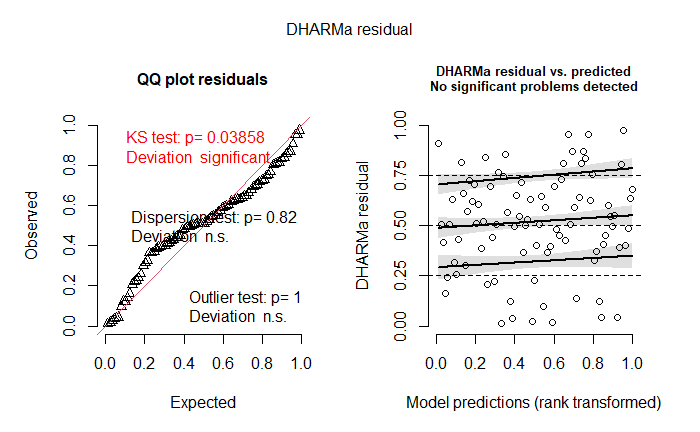

```r
# 1) Observed response (numeric vector)
y_obs <- df$Deaths_em

# 2) Fitted expected counts on response scale (numeric vector, same length as y_obs)
y_hat <- as.numeric(predict(fit, type = "response")$est)

# 3) Simulate from the fitted model (nsim columns)
nsim <- 500
sim_mat <- simulate(fit, nsim = nsim)  # returns a list or matrix depending on version
# coerce to matrix with rows = observations, cols = sims
if (is.list(sim_mat)) sim_mat <- do.call(cbind, sim_mat)
sim_mat <- apply(sim_mat, 2, as.numeric)

# 4) Build DHARMa object
res <- createDHARMa(
  simulatedResponse          = sim_mat,
  observedResponse           = as.numeric(y_obs),
  fittedPredictedResponse    = y_hat,
  integerResponse            = TRUE
)

plot(res)                 # standard DHARMa diagnostics
```

```
    DHARMa nonparametric dispersion test via sd of residuals fitted vs. simulated

data:  simulationOutput
dispersion = 1.0135, p-value = 0.82
alternative hypothesis: two.sided
```

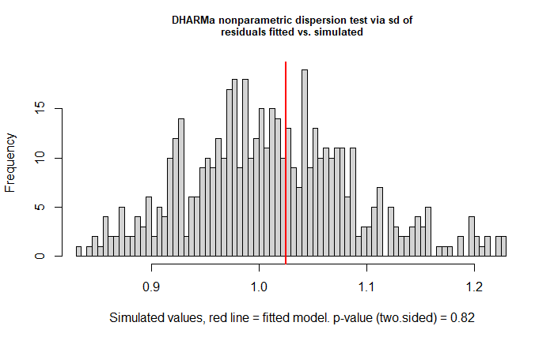

```r
testDispersion(res)       # over/under dispersion check
```

```
    DHARMa zero-inflation test via comparison to expected zeros with simulation
    under H0 = fitted model

data:  simulationOutput
ratioObsSim = 1.1039, p-value = 0.58
alternative hypothesis: two.sided
```

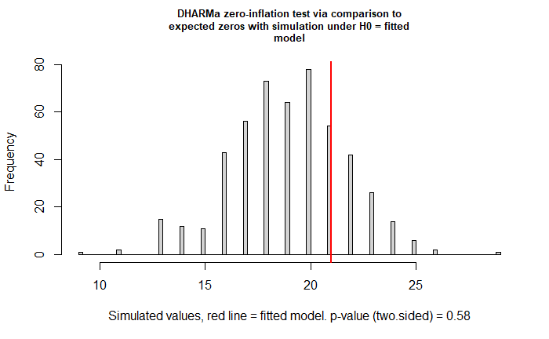

```r
testZeroInflation(res)    # zero inflation check
```

```
    Durbin-Watson test

data:  simulationOutput$scaledResiduals ~ 1
DW = 1.7509, p-value = 0.2394
alternative hypothesis: true autocorrelation is not 0
```

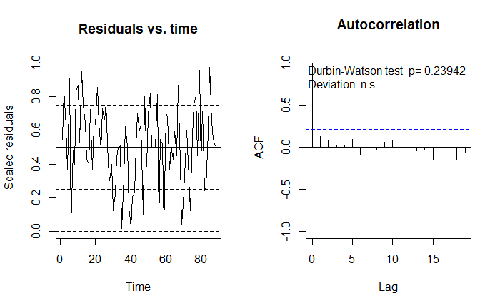

```r
testTemporalAutocorrelation(res, time = df$time_arg)  # optional, if you have time index
```

## 6 PCA Method [New]

### 6.1 Build composite indices (PCA)

```r
# ---- choose variables ----
opioid_vars <- c("OXYCODONE_annual_percapita",
                 "HYDROCODONE_annual_percapita",
                 "BUPRENORPHINE_annual_percapita",
                 "METHADONE_annual_percapita")

ses_vars <- c("poverty_rate", "disability_rate", "noinsurance_rate",
              "unemployee_rate", "gini_index")

# Ensure numeric and drop rows with all-NA in a block
X_opioid <- df %>% select(all_of(opioid_vars)) %>% mutate(across(everything(), as.numeric))
X_ses    <- df %>% select(all_of(ses_vars))    %>% mutate(across(everything(), as.numeric))

# ---- PCA (columns standardized automatically with scale.=TRUE) ----
pca_opioid <- prcomp(na.omit(X_opioid), scale. = TRUE)
pca_ses    <- prcomp(na.omit(X_ses),    scale. = TRUE)

# helper to project with NA handling
project_pc1 <- function(X, pca){
  # center/scale with training means/sds from prcomp
  Xcs <- sweep(X, 2, pca$center, "-")
  Xcs <- sweep(Xcs, 2, pca$scale,  "/")
  # PC1 scores (first loading vector)
  as.numeric(as.matrix(Xcs) %*% pca$rotation[,1])
}

# add indices to df (aligned by row order; if NA rows exist, PC1 will be NA)
df <- df %>%
  mutate(
    Opioid_Index   = project_pc1(select(., all_of(opioid_vars)), pca_opioid),
    SES_Index      = project_pc1(select(., all_of(ses_vars)),    pca_ses)
  ) %>%
  # z-standardize indices for interpretability
  mutate(
    Opioid_Index_z = as.numeric(scale(Opioid_Index)),
    SES_Index_z    = as.numeric(scale(SES_Index)),
    ER_annual_percapita_z = as.numeric(scale(ER_annual_percapita))
  )

# (optional) flip signs so “higher = worse” if desired
if (cor(df$Opioid_Index_z, df$OXYCODONE_annual_percapita, use="pair") < 0) {
  df$Opioid_Index_z <- -df$Opioid_Index_z
}
if (cor(df$SES_Index_z, df$poverty_rate, use="pair") < 0) {
  df$SES_Index_z <- -df$SES_Index_z
}
```

#### 6.1.1 Dectect which varible is the most important

```r
# Loadings (weights) for PC1 in each PCA
round(pca_opioid$rotation[, 1, drop = FALSE], 3)
```

```
                                 PC1
OXYCODONE_annual_percapita     0.592
HYDROCODONE_annual_percapita   0.577
BUPRENORPHINE_annual_percapita 0.472
METHADONE_annual_percapita     0.306
```

```r
round(pca_ses$rotation[, 1, drop = FALSE], 3)
```

```
                   PC1
poverty_rate     0.519
disability_rate  0.452
noinsurance_rate 0.341
unemployee_rate  0.535
gini_index       0.353
```

```r
sort(abs(pca_opioid$rotation[, 1]), decreasing = TRUE)
```

```
    OXYCODONE_annual_percapita   HYDROCODONE_annual_percapita
                     0.5922758                      0.5773643
BUPRENORPHINE_annual_percapita     METHADONE_annual_percapita
                     0.4716813                      0.3055758
```

```r
sort(abs(pca_ses$rotation[, 1]), decreasing = TRUE)
```

```
 unemployee_rate     poverty_rate  disability_rate       gini_index noinsurance_rate
       0.5350776        0.5187269        0.4515141        0.3531002        0.3406899
```

### 6.2 Fit a simpler NB2 model with the key interaction

```r
form_nb <- as.formula(
  Deaths_em ~ ER_annual_percapita_z * Opioid_Index_z * SES_Index_z + year
  # If your DV is a *rate*: use Deaths_em_rate ~ ... (and remove offset below)
)

fit_nb <- sdmTMB(
  formula = form_nb,
  data = df,
  mesh = mesh,
  family = nbinom2(link = "log"),
  spatial = "on",            # or "off" if you prefer
  spatiotemporal = "ar1",    # try "ar1" later if needed
  time = "time_index",               # or "time_index" when using spatiotemporal != "off"
  offset = df$log_pop,       # <— keep only if DV is a *count*
  control = sdmTMBcontrol(newton_loops = 3)
)

summary(fit_nb)
```

```
Spatiotemporal model fit by ML ['sdmTMB']
Formula: form_nb
Mesh: mesh (isotropic covariance)
Time column: time_index
Data: df
Family: nbinom2(link = 'log')

Conditional model:
                                                 coef.est coef.se
(Intercept)                                       -291.60     NaN
ER_annual_percapita_z                               -0.15    0.12
Opioid_Index_z                                       0.19    0.13
SES_Index_z                                          0.03    0.20
year                                                 0.14     NaN
ER_annual_percapita_z:Opioid_Index_z                -0.10    0.13
ER_annual_percapita_z:SES_Index_z                    0.22    0.20
Opioid_Index_z:SES_Index_z                          -0.02    0.13
ER_annual_percapita_z:Opioid_Index_z:SES_Index_z     0.03    0.16

Dispersion parameter: 1472396630666.43
Spatiotemporal AR1 correlation (rho): 0.97
Matérn range: 93.41
Spatial SD: 0.00
Spatiotemporal marginal AR1 SD: 0.59
ML criterion at convergence: 201.485

See ?tidy.sdmTMB to extract these values as a data frame.

**Possible issues detected! Check output of sanity().**
```

## 10 Archived

### 5.6 Hurdle [Not work]

```r
# fit_delta <- sdmTMB(
#   Deaths_em ~ ER_annual_percapita_z + OXYCODONE_annual_percapita_z +
#     HYDROCODONE_annual_percapita_z + BUPRENORPHINE_annual_percapita_z +
#     METHADONE_annual_percapita_z + unemployee_rate_z + gini_index_z +
#     poverty_rate_z + disability_rate_z + noinsurance_rate_z,
#   data = df,
#   mesh = mesh,
#   #family = delta_gamma(link1 = "logit", link2 = "log"),
#   family = nbinom1(link = "log"),
#   spatial = "on",
#   spatiotemporal = "iid",       # or "ar1" / "off"
#   zi = ~ 1,
#   time = "time_index",
#   offset = df$log_pop,          # optional: applies to the positive part
#   control = sdmTMBcontrol(newton_loops = 2)
# )
# summary(fit_delta)
```

### 5.7 Two-part Hurdle [Under tuning]

```r
# identify variable positions by name pattern
drug_idx <- grepl("OXYCODONE|HYDROCODONE|BUPRENORPHINE|METHADONE", Xnames, ignore.case = TRUE)
```

```
Error: object 'Xnames' not found
```

#### 5.7.1 Extract and Interpret Coefficients

```r
tab_zero <- tidy(fit_zero, effects = "fixed", conf.int = TRUE) %>%
  mutate(
    z_value = estimate / std.error,
    p_value = 2 * (1 - pnorm(abs(z_value))),
    p_value = case_when(           # easy-read rounding
      p_value < 0.001 ~ "< .001",
      TRUE            ~ sprintf("%.3f", round(p_value, 3))
    )
  )

tab_pos <- tidy(fit_pos, effects = "fixed", conf.int = TRUE) %>%
  mutate(
    z_value = estimate / std.error,
    p_value = 2 * (1 - pnorm(abs(z_value))),
    p_value = case_when(
      p_value < 0.001 ~ "< .001",
      TRUE            ~ sprintf("%.3f", round(p_value, 3))
    ),
    exp_est = exp(estimate),
    exp_lo  = exp(conf.low),
    exp_hi  = exp(conf.high)
  )


# Hurdle: Zero Model Part
tab_zero
```

```r
### Hurdle: Positive Model Part
tab_pos
```

#### 5.7.2 Model Fit

```r
# --- 1) Figure out which rows are usable for each part ---------------------
# Zero part needs RHS in form_zero
mf_zero  <- model.frame(form_zero, data = df)
keep_zero <- complete.cases(mf_zero)

# Positive part needs RHS in form_pos AND a finite offset
mf_pos   <- model.frame(form_pos,  data = df)
keep_pos <- complete.cases(mf_pos) & is.finite(df$log_pop)

# Rows where both parts can be predicted
keep_both <- keep_zero & keep_pos

# --- 2) Predict each part on the kept rows ---------------------------------
# Pr(Y>0 | x)
p_pos <- rep(NA_real_, nrow(df))
p_pos[keep_zero] <- plogis(
  predict(fit_zero, type = "link",
          newdata = df[keep_zero, , drop = FALSE],
          allow_new_levels = TRUE)$est
)

# E[Y | Y>0, x]
mu_pos <- rep(NA_real_, nrow(df))
mu_pos[keep_pos] <- exp(
  predict(fit_pos, type = "link",
          newdata = df[keep_pos, , drop = FALSE],
          offset  = df$log_pop[keep_pos],
          allow_new_levels = TRUE)$est
)

# --- 3) Combine into expected deaths and attach ----------------------------
E_Y <- rep(NA_real_, nrow(df))
E_Y[keep_both] <- p_pos[keep_both] * mu_pos[keep_both]
df$E_Y <- E_Y

# --- 4) Plot observed vs expected on rows with both available --------------
ok <- is.finite(df$E_Y) & is.finite(df$Deaths_em)
plot(df$E_Y[ok], df$Deaths_em[ok], xlab = "Expected", ylab = "Observed")
abline(0, 1, col = "red", lwd = 2)

# Optional quick diagnostics
cor(df$E_Y[ok], df$Deaths_em[ok])
hist((df$Deaths_em - df$E_Y)[ok], main = "Raw residuals", xlab = "Obs - Exp")
```

```r
df$resid <- df$Deaths_em - df$E_Y
hist(df$resid)
boxplot(resid ~ time_index, data=df)
```